# **RStudio Exercise 3: Logistic Regression**

For explanation how the data set was created see: https://mooc.helsinki.fi/course/view.php?id=273#section-3 and R script: https://github.com/ohwhalme/IODS-project/blob/master/data/data_ex3.R

#### **Oppening the data file and inspecting data form and structure**:

```r
data <- read.csv("C:/Users/OHW/Desktop/R/IODS-project/data/alc.csv")
data <- dplyr::rename(data, ID = X)
str(data)
```

```
## 'data.frame':    382 obs. of  36 variables:
##  $ ID        : int  1 2 3 4 5 6 7 8 9 10 ...
##  $ school    : Factor w/ 2 levels "GP","MS": 1 1 1 1 1 1 1 1 1 1 ...
##  $ sex       : Factor w/ 2 levels "F","M": 1 1 1 1 1 2 2 1 2 2 ...
##  $ age       : int  18 17 15 15 16 16 16 17 15 15 ...
##  $ address   : Factor w/ 2 levels "R","U": 2 2 2 2 2 2 2 2 2 2 ...
##  $ famsize   : Factor w/ 2 levels "GT3","LE3": 1 1 2 1 1 2 2 1 2 1 ...
##  $ Pstatus   : Factor w/ 2 levels "A","T": 1 2 2 2 2 2 2 1 1 2 ...
##  $ Medu      : int  4 1 1 4 3 4 2 4 3 3 ...
##  $ Fedu      : int  4 1 1 2 3 3 2 4 2 4 ...
##  $ Mjob      : Factor w/ 5 levels "at_home","health",..: 1 1 1 2 3 4 3 3 4 3 ...
##  $ Fjob      : Factor w/ 5 levels "at_home","health",..: 5 3 3 4 3 3 3 5 3 3 ...
##  $ reason    : Factor w/ 4 levels "course","home",..: 1 1 3 2 2 4 2 2 2 2 ...
##  $ nursery   : Factor w/ 2 levels "no","yes": 2 1 2 2 2 2 2 2 2 2 ...
##  $ internet  : Factor w/ 2 levels "no","yes": 1 2 2 2 1 2 2 1 2 2 ...
```

[output cut: 22 more lines]

```r
glimpse(data)
```

```
## Observations: 382
## Variables: 36
## $ ID         <int> 1, 2, 3, 4, 5, 6, 7, 8, 9, 10, 11, 12, 13, 14, 15, ...
## $ school     <fct> GP, GP, GP, GP, GP, GP, GP, GP, GP, GP, GP, GP, GP,...
## $ sex        <fct> F, F, F, F, F, M, M, F, M, M, F, F, M, M, M, F, F, ...
## $ age        <int> 18, 17, 15, 15, 16, 16, 16, 17, 15, 15, 15, 15, 15,...
## $ address    <fct> U, U, U, U, U, U, U, U, U, U, U, U, U, U, U, U, U, ...
## $ famsize    <fct> GT3, GT3, LE3, GT3, GT3, LE3, LE3, GT3, LE3, GT3, G...
## $ Pstatus    <fct> A, T, T, T, T, T, T, A, A, T, T, T, T, T, A, T, T, ...
## $ Medu       <int> 4, 1, 1, 4, 3, 4, 2, 4, 3, 3, 4, 2, 4, 4, 2, 4, 4, ...
## $ Fedu       <int> 4, 1, 1, 2, 3, 3, 2, 4, 2, 4, 4, 1, 4, 3, 2, 4, 4, ...
## $ Mjob       <fct> at_home, at_home, at_home, health, other, services,...
## $ Fjob       <fct> teacher, other, other, services, other, other, othe...
## $ reason     <fct> course, course, other, home, home, reputation, home...
## $ nursery    <fct> yes, no, yes, yes, yes, yes, yes, yes, yes, yes, ye...
```

[output cut: 23 more lines]

```r
any(is.na.data.frame(data))
```

```
## [1] FALSE
```

There are no missing values. The data contains 382 observations (rows) and 35 + 1 variables (columns). + 1 being participant ID. Thorough description of the variables in the original data set is given here: https://archive.ics.uci.edu/ml/datasets/Student+Performance

**Note that following data transformations were done before starting the analysis:**

- The variables not used for joining the two data have been combined by averaging (including the grade variables)
- ‘alc_use’ is the average of ‘Dalc’ and ‘Walc’
- ‘high_use’ is TRUE if ‘alc_use’ is higher than 2 and FALSE otherwise

#### **Selecting variables and presenting hypotheses**:

Respose variable will be the aforementioned **“high_use”**, which indicates whether participant consumes large amounts of alcohol (TRUE if participants averaged workday and weekend alcohol consumption is more than 2; where 1 is “very low” and 5 is “very high”).

In general, men tend to drink more than women (for example, [Wilsnack & Wilsnack, 2013](https://psycnet.apa.org/record/2013-24934-017)), so I think adding gender (**“sex”**) to the model could help us identify heavy drinkers (binary: female/male).

Many times drinking is also social activity, so I think there might be a positive association between available leisure time and drinking (**“freetime”** i.e. free time after school, where 1 is very low and 5 is very high), and between going out with friends and drinking (**“goout”**, where 1 is very low and 5 is very high).

With the same logic I assume that there could be a negative association between being involved in extra-curricular activities (**“activities”**) and heavy drinking (binary: yes/no).

#### **Exploring the distributions of the chosen variables and their relationships with alcohol consumption**

First let’s examine what are the variable frequencies.

**High alcohol use**

```r
summarytools::freq(data$high_use, order = "freq", totals = FALSE)
```

```
## Frequencies
## data$high_use
## Type: Logical
##
##               Freq   % Valid   % Valid Cum.   % Total   % Total Cum.
## ----------- ------ --------- -------------- --------- --------------
##       FALSE    268     70.16          70.16     70.16          70.16
##        TRUE    114     29.84         100.00     29.84         100.00
##        <NA>      0                               0.00         100.00
```

**Participant gender**

```
## Frequencies
## data$sex
## Type: Factor
##
##              Freq   % Valid   % Valid Cum.   % Total   % Total Cum.
## ---------- ------ --------- -------------- --------- --------------
##          F    198     51.83          51.83     51.83          51.83
##          M    184     48.17         100.00     48.17         100.00
##       <NA>      0                               0.00         100.00
```

**Extra-curricular activities**

```
## Frequencies
## data$activities
## Type: Factor
##
##              Freq   % Valid   % Valid Cum.   % Total   % Total Cum.
## ---------- ------ --------- -------------- --------- --------------
##        yes    201     52.62          52.62     52.62          52.62
##         no    181     47.38         100.00     47.38         100.00
##       <NA>      0                               0.00         100.00
```

**Free time after school**

```
## Frequencies
## data$freetime
##
##              Freq   % Valid   % Valid Cum.   % Total   % Total Cum.
## ---------- ------ --------- -------------- --------- --------------
##          3    153     40.05          40.05     40.05          40.05
##          4    111     29.06          69.11     29.06          69.11
##          2     65     17.02          86.13     17.02          86.13
##          5     36      9.42          95.55      9.42          95.55
##          1     17      4.45         100.00      4.45         100.00
##       <NA>      0                               0.00         100.00
```

**Going out with friends**

```
## Frequencies
## data$goout
##
##              Freq   % Valid   % Valid Cum.   % Total   % Total Cum.
## ---------- ------ --------- -------------- --------- --------------
##          3    126     32.98          32.98     32.98          32.98
##          2    100     26.18          59.16     26.18          59.16
##          4     81     21.20          80.37     21.20          80.37
##          5     53     13.87          94.24     13.87          94.24
##          1     22      5.76         100.00      5.76         100.00
##       <NA>      0                               0.00         100.00
```

From here we can see that 29.84 % of participants are classified as heavy users, 51.83 % are female, and 52.62 % are involved in extra-curricular activities. Looking at the valid percentages “freetime” and “goout” variables seems to be fairly normally distributed. To be sure, let’s also examine bar plots for these variables.

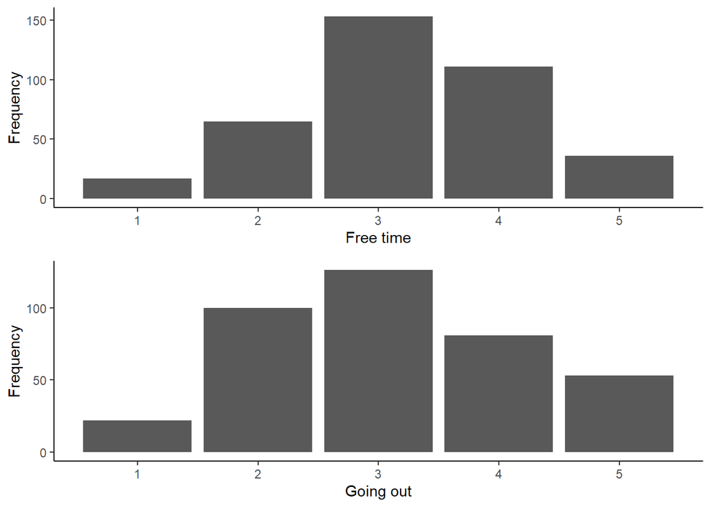

```r
freetime_aes <- ggplot(data, aes(data$freetime))
goout_aes <- ggplot(data, aes(data$goout))
B1 <- freetime_aes + geom_bar() + labs(x = "Free time", y = "Frequency") + theme_classic()
B2 <- goout_aes + geom_bar() + labs(x = "Going out", y = "Frequency") + theme_classic()
gridExtra::grid.arrange(B1, B2, nrow = 2)
```

Bar plots confirms that the two interval variables seem to follow approximately the gaussian distribution. Next let’s see how each of the explanatory variables are related to the response variable “high_use”.

**Participant gender x High use (cross-tabulation)**

```r
summarytools::ctable(data$sex, data$high_use)
```

```
## Cross-Tabulation, Row Proportions
## sex * high_use
## Data Frame: data
##
## ------- ---------- ------------- ------------- --------------
##           high_use         FALSE          TRUE          Total
##     sex
##       F              156 (78.8%)    42 (21.2%)   198 (100.0%)
##       M              112 (60.9%)    72 (39.1%)   184 (100.0%)
##   Total              268 (70.2%)   114 (29.8%)   382 (100.0%)
## ------- ---------- ------------- ------------- --------------
```

```r
chi1 <- chisq.test(data$sex, data$high_use)
chi1
```

```
##
##  Pearson's Chi-squared test with Yates' continuity correction
##
## data:  data$sex and data$high_use
## X-squared = 13.782, df = 1, p-value = 0.0002053
```

```r
round(chi1$residuals, 3)
```

```
##         data$high_use
## data$sex  FALSE   TRUE
##        F  1.450 -2.223
##        M -1.504  2.306
```

There seems to be a statistically significant association between participant gender and heavy drinking, X2(1) = 13.782, p < .001. From the residuals we can see that females are more represented in the FALSE category and less in the TRUE category than what would be expected if the counts were equally distributed among the cells in the cross-tabulation. Opposite trend can be observed for males. Seems that our initial guess was a correct, males are more likely to be high drinkers than females (39.1 % vs 21.2 %, respectively).

**Extra-curricular activities x High use (cross-tabulation)**

```
## Cross-Tabulation, Row Proportions
## activities * high_use
## Data Frame: data
##
## ------------ ---------- ------------- ------------- --------------
##                high_use         FALSE          TRUE          Total
##   activities
##           no              122 (67.4%)    59 (32.6%)   181 (100.0%)
##          yes              146 (72.6%)    55 (27.4%)   201 (100.0%)
##        Total              268 (70.2%)   114 (29.8%)   382 (100.0%)
## ------------ ---------- ------------- ------------- --------------
```

```
##
##  Pearson's Chi-squared test with Yates' continuity correction
##
## data:  data$activities and data$high_use
## X-squared = 1.0085, df = 1, p-value = 0.3153
```

```
##                data$high_use
## data$activities  FALSE   TRUE
##             no  -0.442  0.678
##             yes  0.420 -0.644
```

At first glance, it seems that there is a association between being involved in extra-curricular activities and drinking less (27.4 % vs 32.6 % for high drinking). However, inspection of the chi-square statistic indicates that this association is rather faint, and not statistically significant at the .05 alpha level, X2(1) = 1.0085, p = .32.

**Free time x High use (cross-tabulation)**

```
## Cross-Tabulation, Row Proportions
## freetime * high_use
## Data Frame: data
##
## ---------- ---------- ------------- ------------- --------------
##              high_use         FALSE          TRUE          Total
##   freetime
##          1               15 (88.2%)     2 (11.8%)    17 (100.0%)
##          2               49 (75.4%)    16 (24.6%)    65 (100.0%)
##          3              113 (73.9%)    40 (26.1%)   153 (100.0%)
##          4               70 (63.1%)    41 (36.9%)   111 (100.0%)
##          5               21 (58.3%)    15 (41.7%)    36 (100.0%)
##      Total              268 (70.2%)   114 (29.8%)   382 (100.0%)
## ---------- ---------- ------------- ------------- --------------
```

```
##
##  Pearson's Chi-squared test
##
## data:  data$freetime and data$high_use
## X-squared = 9.5739, df = 4, p-value = 0.04825
```

```
##              data$high_use
## data$freetime  FALSE   TRUE
##             1  0.890 -1.364
##             2  0.503 -0.771
##             3  0.546 -0.838
##             4 -0.892  1.368
##             5 -0.847  1.299
```

The p-value associateed with the test statistic barely undercuts the conventional .05 alpha level, X2(4) = 9.5739, p = .04825. From the residuals we can see that the strongest negative assocciation between the two variable levels seem to be between “freetime” value 1 and when “high_use” is TRUE, and strongest positive association when “freetime” value is 4 or 5 and “high_use” is TRUE. This indicates that there is a association between having lot’s of free time and also being a heavy drinker (the same trend can also be noted when cross-tabulation percentages are eyeballed).

**Going out x High use (cross-tabulation)**

```
## Cross-Tabulation, Row Proportions
## goout * high_use
## Data Frame: data
##
## ------- ---------- ------------- ------------- --------------
##           high_use         FALSE          TRUE          Total
##   goout
##       1               19 (86.4%)     3 (13.6%)    22 (100.0%)
##       2               84 (84.0%)    16 (16.0%)   100 (100.0%)
##       3              103 (81.7%)    23 (18.3%)   126 (100.0%)
##       4               41 (50.6%)    40 (49.4%)    81 (100.0%)
##       5               21 (39.6%)    32 (60.4%)    53 (100.0%)
##   Total              268 (70.2%)   114 (29.8%)   382 (100.0%)
## ------- ---------- ------------- ------------- --------------
```

```
##
##  Pearson's Chi-squared test
##
## data:  data$goout and data$high_use
## X-squared = 58.368, df = 4, p-value = 6.388e-12
```

```
##           data$high_use
## data$goout  FALSE   TRUE
##          1  0.908 -1.391
##          2  1.653 -2.534
##          3  1.553 -2.381
##          4 -2.100  3.219
##          5 -2.654  4.069
```

Looking at the percentages it seems clear that going out more often is associated with high alcohol use (from “goout” values 1 to 3 percentage of high users are 13.6-18.3 %, and from values 4 to 5 percentage of high users are 49.4-60.4 %). The chi-square statistic and respective residuals give support for this observation, X2(4) = 58.368, p < .001.

To sum up, the cross-tabulations and associated chi-square tests seem to provide some support for our initial hypotheses concerning the relation between high alcohol use and the explanatory variables (with exception of “activities” and “high_use”). Next, we will investigate how these variables can be used to predict high alcohol use in logistic regression model.

#### **Logistic regression: Model fitting and interpretation**

Based on our earlier inspections, it seems that participant gender and how often participant goes out with friends are the best predictors of high alcohol use. So we’ll start with a model where “sex” and “goout” are used to predict “high_use” and then we’ll add the rest of the explanatory variables to see if our model fit improves.

**Model 1: High alchohol use ~ Participant gender + Going out with friends**

```r
model1 <- glm(high_use ~ goout + sex, family=binomial(link='logit'), data=data)
summary(model1)
```

```
##
## Call:
## glm(formula = high_use ~ goout + sex, family = binomial(link = "logit"),
##     data = data)
##
## Deviance Residuals:
##     Min       1Q   Median       3Q      Max
## -1.5599  -0.8726  -0.6260   0.8382   2.4893
##
## Coefficients:
##             Estimate Std. Error z value Pr(>|z|)
## (Intercept)  -3.8130     0.4529  -8.420  < 2e-16 ***
## goout         0.7609     0.1181   6.441 1.19e-10 ***
## sexM          0.8736     0.2466   3.543 0.000396 ***
## ---
## Signif. codes:  0 '***' 0.001 '**' 0.01 '*' 0.05 '.' 0.1 ' ' 1
##
## (Dispersion parameter for binomial family taken to be 1)
##
##     Null deviance: 465.68  on 381  degrees of freedom
## Residual deviance: 402.74  on 379  degrees of freedom
## AIC: 408.74
##
## Number of Fisher Scoring iterations: 4
```

**Model 2: High alchohol use ~ Participant gender + Going out with friends + Leisure time + Extra-curricular activities**

```r
model2 <- glm(high_use ~ goout + sex + freetime + activities, family=binomial(link='logit'), data=data)
summary(model2)
```

```
##
## Call:
## glm(formula = high_use ~ goout + sex + freetime + activities,
##     family = binomial(link = "logit"), data = data)
##
## Deviance Residuals:
##     Min       1Q   Median       3Q      Max
## -1.7013  -0.8085  -0.5526   0.8744   2.6147
##
## Coefficients:
##               Estimate Std. Error z value Pr(>|z|)
## (Intercept)   -3.79200    0.55553  -6.826 8.74e-12 ***
## goout          0.76105    0.12364   6.155 7.49e-10 ***
## sexM           0.92216    0.25420   3.628 0.000286 ***
## freetime       0.06094    0.13468   0.452 0.650949
## activitiesyes -0.47586    0.25025  -1.902 0.057226 .
## ---
## Signif. codes:  0 '***' 0.001 '**' 0.01 '*' 0.05 '.' 0.1 ' ' 1
##
## (Dispersion parameter for binomial family taken to be 1)
##
##     Null deviance: 465.68  on 381  degrees of freedom
## Residual deviance: 398.95  on 377  degrees of freedom
## AIC: 408.95
##
## Number of Fisher Scoring iterations: 4
```

```r
lmtest::lrtest(model1, model2)
```

```
## Likelihood ratio test
##
## Model 1: high_use ~ goout + sex
## Model 2: high_use ~ goout + sex + freetime + activities
##   #Df  LogLik Df  Chisq Pr(>Chisq)
## 1   3 -201.37
## 2   5 -199.47  2 3.7952     0.1499
```

First of all, we can see that “goout” and “sex” are significant predictors of “high_use” in both models, while “freetime” and “activities” are not when all the other variables are kept constant in the model. Including “freetime” and “activities” does not noticeably change the coefficients of “goout” and “sex”. Moreover, when model 1 and 2 are compared against the null model (i.e. intercept only) we can see that there is a slight decrease in residual deviance in model 2 compared to model 1, but AIC ([Akaike Information Criterion](https://en.wikipedia.org/wiki/Akaike_information_criterion)), which also takes into account how many new variables have been added (i.e. risk of overfitting), does not decrease. This is also confirmed by the partial likelihood ratio test, which indicates that the two models are not significantly different in their fits for the data (p = .15). Taken together, this means that we are probably better off predicting “high_use” with the simpler model 1.

**Interpreting the model coefficients**

```r
OR <- coef(model1) %>% exp
CI <- confint(model1) %>% exp
cbind(OR, CI)
```

```
##                     OR       2.5 %     97.5 %
## (Intercept) 0.02208168 0.008754964 0.05186666
## goout       2.14025612 1.708110942 2.71701439
## sexM        2.39559680 1.484457552 3.91015147
```

The model coefficients represent the expected change in the log odds of “high_use” when the particular explanatory variable increases one unit (keeping all the other variables constant in the model). The odds ratio is calculated by taking exp() function of these coefficients, and thus indicates the proportionate change in odds between the explanatory variable levels. Here, OR for “goout” is 2.14 which means that when “goout” variable increases one unit, the odds of participant belonging to high alcohol use category are, on average, 2.14 times greater. “Sex” is a binary variable but the interperation is much the same, when one unit increase takes place (i.e. when we go from female to male category) odds of belonging to high alcohol use category goes up 2.40 times. Thus, both, being a male and going out with friends more often, increases the participants risk of being a heavy drinker (which is in line with our earlier hypotheses). Confidence intervals indicate that the direction of the ORs received here will likely be same as they are in the population (CIs dont include 1).

**Model accuracy**

```r
probabilities <- predict(model1, type = "response")
data <- mutate(data, probability = probabilities)
data <- mutate(data, prediction = probability > 0.5)
table(high_use = data$high_use, prediction = data$prediction)
```

```
##         prediction
## high_use FALSE TRUE
##    FALSE   251   17
##    TRUE     63   51
```

```r
InformationValue::misClassError(data$high_use, data$prediction, threshold = 0.5)
```

```
## [1] 0.2094
```

From here we can see that our model correctly identifies 251 out of 268 cases as being “moderate drinkers”, and 51 out of 114 cases as being heavy drinkers (when treshold level is kept at 0.5). This leads to average number of wrong predictions being 0.2094 (i.e. accuracy is approximately 79 %). Even though our model is quite good at predicting **who is not a heavy drinker** (251/268 = 0.94) it performs worse than change level alone when predicting **who is a heavy drinker** (51/114 = 0.45).

Before wrapping up, let’s take a quick look at some of the model diagnostics.

**Model diagnostics**

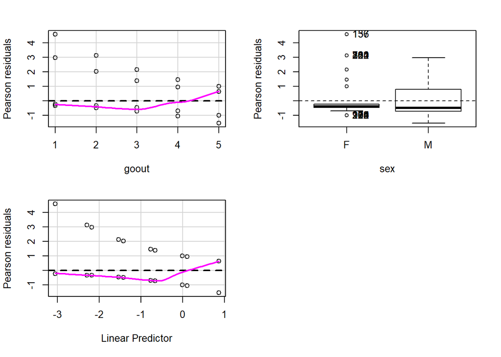

```
##       Test stat Pr(>|Test stat|)
## goout    1.3564           0.2442
## sex
```

```r
car::residualPlots(model1)
```

Above we have plotted the pearson residuals of the model against the predictors fitted values. Ideally we would see straight horizontal line without curvature indicating that there is correlation between residuals and the fitted values. Here, slight curvature can be seen, but, as the more formal test of curvature indicates, there does not seem to be a major problem with-in the model (p = .24).

Next we’ll check if we can spot any outliers in the model.

```r
car::outlierTest(model1)
```

```
## No Studentized residuals with Bonferroni p < 0.05
## Largest |rstudent|:
##     rstudent unadjusted p-value Bonferroni p
## 136 2.511506           0.012022           NA
```

The results show that there is no outliers as judged by Bonferonni p. Largest studenized residual seems to be 2.51 (for case 136), which is still not alarmingly large (i.e. above 3).

Next let’s see if we can find influential values in our model.

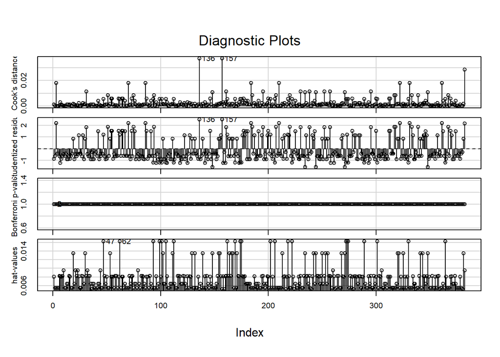

```r
car::influenceIndexPlot(model1)
```

Here the most interesting plot is the one showing the Cook’s distance values. The same case that was mentioned earlier (136) is highlighted also here. However, all of the Cooks distance values are rather low (<.04), so we probably don’t have cause for serious concern.

**Bonus: Cross-validitation**

```r
loss_func <- function(class, prob) {
  n_wrong <- abs(class - prob) > 0.5
  mean(n_wrong)
}

loss_func(data$high_use, data$probability)
```

```
## [1] 0.2094241
```

```r
library(boot)
cv <- cv.glm(data = data, cost = loss_func, glmfit = model1, K = 10)
cv$delta[1]
```

```
## [1] 0.2329843
```

10-fold cross-validitation of the model gives us fairly similar accuracy estimation as our original data (mean wrong = 0.2329843 % vs 0.2094241 %, respectively).